# INFO-332 Exploratory Data Analytics

## **Lesson 1: Introduction to the R Programming Language**

Prepared by Dr. Maher Harb; version 1.4 (20/21 Spring); last updated March 05, 2021.

## **About the lesson**

This lesson introduces the R programming language, the RStudio development environment, and basic data types in R, including vectors, matrices and data frames.

To get the most out of the lesson, it is recommended to execute the inline code in this Notebook on your own machine and to make sure that you understand the syntax of the code as well as the intended functionality.

## **1. About R**

R is an open source programming language that originated from the statistics community with the intention of providing an easy to learn and use platform for statistical computing and graphing tasks. Today, R’s popularity goes well beyond the field of statistics. Along python, R is one of the popular choices for performing exploratory data analysis, implementing end-to-end data science pipelines, and building machine learning models. The success of R has to do with the following factors:

- Since its inception, R has been open source and free to use
- R is expandable; any user can develop a package (library) that expands R’s functionality beyond core R (also referred to as R Base)
- R enjoys strong support from the open source community
- R is relatively easy to learn even for users outside core STEM areas; e.g. R is also popular in the social sciences

In this course, we will use R through the RStudio development environment. RStudio has a full-featured text editor that makes it easier to write R code, as well as other useful features that we’ll learn about during this course.

Let’s begin the journey to learn R!

## **2. Installing R and RStudio**

Your first order of business is to install R and RStudio (in this order) on your machine. Both R and RStudio are available for Windows, MacOS, and Linux. Here are some useful links to get you started:

- Download R from: https://www.r-project.org/
- Download RStudio from: https://www.rstudio.com/

For each software, locate the version that is appropriate for your operating system, then install it.

## **3. The RStudio Interface**

Note that when using the RStudio development environment, you’ll never have to run R! By opening RStudio, R will run in the background. Hence, think of RStudio as your single point of entry to editing and running R code.

Open RStudio and take a look at the RStudio interface (shown in the figure below).

[figure not shown]

(Image of The RStudio Interface)

The RStudio interface has four main areas (windows):

- Bottom-left: The console
- Top-left: The editor
- Bottom-right: Files, Plots, Packages, Help, Viewer
- Top-right: Environment, History (and depending on the RStudio version, some other tabs)

As you get to use RStudio, you’ll eventually become familiar with most of these components. But for now, let’s highlight the most important components of the interface to get you started.

### **3.1 The console**

The console offers direct access to the R environment. Commands typed in the console are executed once the **return** key is pressed. Example:

```r
1+1
```

```
## [1] 2
```

Notice that R returns the result of the calculation. The `[1]` refers to the line number of the output. In this example, the output is a single line.

Try executing an expression from the console. Example, here’s one that calculates the circumference of earth in km:

```r
2*pi*6371
```

```
## [1] 40030.17
```

In its simplest form, the console could be used as a calculator!

### **3.2 The editor**

The console is useful for doing quick calculations and checking the variables in the environment. However, using the console exclusively will not allow you to back track your steps and to author and share reproducible code. The editor is the primary tool for writing and saving code. The RStudio editor has built-in formatting features that are useful for organizing code so that it becomes easier to follow logical blocks within your script and to track and correct syntax errors. You will spend most of the time developing code in the editor and you’ll get to learn more about it as we progress in the course.

### **3.3 Help**

You will often need to look up documentation on certain functions in R. The quickest way to access the built-in function documentation is by typing ? (question mark) followed by the function name in the console.

Check the following line of code executed from the console:

```r
rnorm(20, 0, 2)
```

```
##  [1] -1.4394327  0.6551070  1.5380455 -1.2899502 -0.4394001  1.6753177
##  [7] -1.1477277  1.3665002 -5.5039826 -5.0979558 -1.0221528  1.6193388
## [13]  2.0621591 -1.8101687 -1.5377987 -3.2342489  2.1273353  1.8608127
## [19]  3.6278426  0.5439044
```

It seems to return a bunch of numbers! To be exact, 20 of them. If you’re wondering what `rnorm` does, you may check that by accessing the help document for `rnorm`:

```
?rnorm
```

Once you hit the return key, the help document will be displayed in the bottom right corner of the interface.

As you may have guessed from reading the documentation, `rnorm` generates random numbers drawn from a normal distribution. If you’re in doubt, here’s a way to verify that by visualizing the distribution for 1 million numbers:

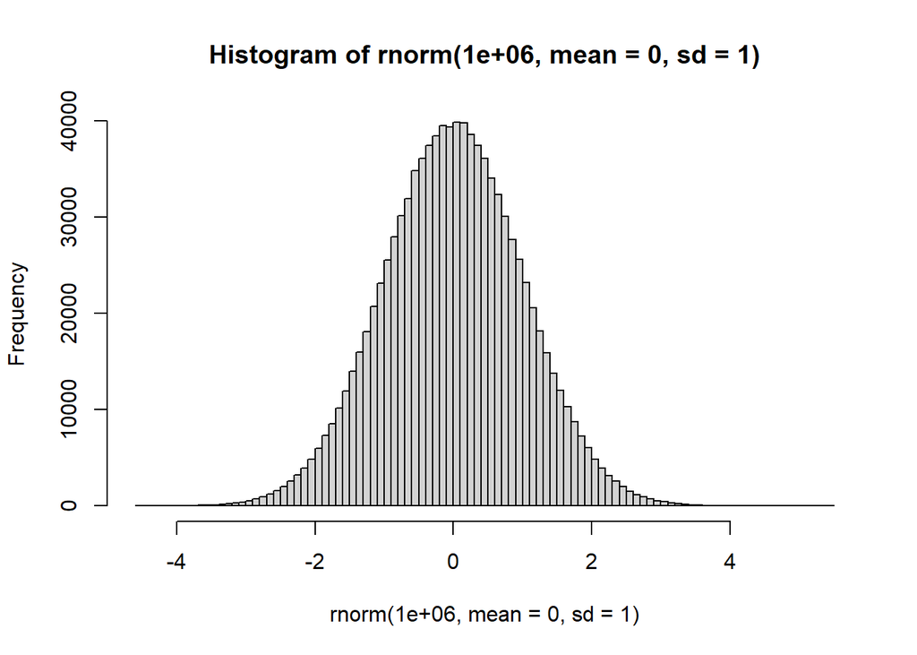

```r
hist(rnorm(1000000,mean=0, sd=1), breaks=100)
```

It looks perfect!

## **4. Variables**

The most basic functionality any programming language offers is the ability to define and assign values to variables. In R, you don’t need to declare the type of a variable (R is a dynamically typed language.). You simply assign a value to the variable using `<-` as shown in this example:

```r
a <- 6
```

Notice the following:

- Nothing is returned by the console. We merely specified that variable `a` is assigned the value 6
- If you now look at the Environment tab in the top right part of the RStudio interface, you’ll see `a` listed as a variable

What if you’d like to check whether `a` is indeed 6? There are few options for doing so, as shown below.

Typing the variable name:

```r
a
```

```
## [1] 6
```

Or using the `print` function:

```r
print(a)
```

```
## [1] 6
```

Another useful function is `class`, used to check the data type of an R variable:

```r
class(a)
```

```
## [1] "numeric"
```

Variable `a` is numeric. This shouldn’t be surprising since we assigned the value 6 to `a`. In R, we don’t explicitly define the data type of a variable. But by assigning a value to a variable, R makes a best guess as to the intended data type.

Now is a good place to discuss the most basic data types in R (also called the atomic data types).

### **4.1 `integer` vs. `numeric` data type**

A number in R can be either an integer or a numeric data type.

When assigning a number to a variable, R assumes that the variable is numeric (not an integer). What’s the distinction? In principle, an integer data type is used for positive and negative whole numbers (i.e. numbers that do not contain decimal points). However, R will always assume that the data type is numeric even when the assigned value is a whole number. Let’s consider this example:

```r
a <- 6
b <- 1.2
```

`a` is a whole number, while `b` is a decimal. Let’s check their data types:

```r
class(a)
```

```
## [1] "numeric"
```

```r
class(b)
```

```
## [1] "numeric"
```

They are both numeric! You can force R to treat `a` as an integer by appending the Capital L letter to the assignment:

```r
a <- 6L
class(a)
```

```
## [1] "integer"
```

Once again, by default R treats all numbers as numeric. We usually don’t bother to explicitly specify that a number should be an integer. There’s one important exception: when we are concerned about the memory requirements for storing the variable. This applies for instance when creating an array of integers with millions or even billions of elements. For this course, we will be satisfied with the default way of doing things in R when it comes to treating all numbers as numeric.

(an integer uses 4 bytes of memory while a numeric uses 8 bytes of memory)

### **4.2 The `logical` data type**

A logical variable takes the values `TRUE` or `FALSE`. This’s known an a *Boolean* in other programming languages.

```r
a <- TRUE
b <- FALSE
class(a)
```

```
## [1] "logical"
```

```r
class(b)
```

```
## [1] "logical"
```

Note that `TRUE` and `FALSE` are written in all CAPS. Using lower or mixed cases does not work. Also note that in arithmetic operations involving numbers and logical data types, `TRUE` and `FALSE` are respectively substituted by 1 and 0. Example:

```r
67 + 3*TRUE
```

```
## [1] 70
```

and

```r
FALSE*1001
```

```
## [1] 0
```

### **4.3 The `character` data type**

In R, variables that contain text strings are character type variables. Text is passed to a variable within double or single quotes. Example:

```r
a <- "This is a message."
b <- 'Hello, Goodbye!'
class(a)
```

```
## [1] "character"
```

```r
class(b)
```

```
## [1] "character"
```

The `paste` function concatenates strings, placing a space in between by default:

```r
paste(a, b)
```

```
## [1] "This is a message. Hello, Goodbye!"
```

### **4.4 The `complex` number data type**

As the name suggests, the complex data type is used for representing complex numbers. In R, the imaginary component of a number is represented by a number followed by the letter `i`. Here’s an example of defining a complex number then applying an arithmetic operation to it:

```
a <- 3 - 4i
```

```r
class(a)
```

```
## [1] "complex"
```

Here’s the value of `a` raised to the power 2:

```r
a^2
```

```
## [1] -7-24i
```

Four useful functions associated with complex numbers are `Re`, `Im`, `Conj`, and `Mod`. As the names suggest, they are respectively used to extract the real part, imaginary part, complex conjugate, and modulus of a complex number.

```r
a
```

```
## [1] 3-4i
```

The real part of `a`:

```r
Re(a)
```

```
## [1] 3
```

The imaginary part of `a`:

```r
Im(a)
```

```
## [1] -4
```

The conjugate of `a`:

```r
Conj(a)
```

```
## [1] 3+4i
```

The modulus of `a`:

```r
Mod(a)
```

```
## [1] 5
```

### **4.5 The raw data type**

Finally there’s the raw data type, which in not used very often but is included here for completeness. Raw variables hold the raw bytes of data. We will not be using raw variables in this course.

## **5. Vectors**

The next important feature of the R language to describe is combining single element values into vectors. Imagine for example, that you wish to record the average daily temperatures in Celsius in your city, over a one week period of time. In R, a vector is created using the `c` function, which is short for concatenate:

```r
daily_temp <- c(14, 15, 19, 22, 20, 14, 13)
class(daily_temp)
```

```
## [1] "numeric"
```

Even though `daily_temp` is a vector, its class follows the class of its basic element, which is numeric. A single element within a vector is accessed using square brackets, with the index of the element in between the brackets. Note that indices in R start from 1 for the first element (unlike languages such as python, in which indices start from 0).

```r
daily_temp[1]
```

```
## [1] 14
```

```r
daily_temp[4]
```

```
## [1] 22
```

Multiple elements are accessed by specifying a range using the : (colon):

```r
daily_temp[2:5]
```

```
## [1] 15 19 22 20
```

and individual non-contiguous elements by enumerating their indices:

```r
daily_temp[c(1, 3, 7)]
```

```
## [1] 14 19 13
```

`length` is used to retrieve the length of a vector:

```r
length(daily_temp)
```

```
## [1] 7
```

### **5.1 Names of vector elements**

Elements of a vector need not, but may have names. Let’s check the names of the elements in our daily temperature vectors using the `names` function:

```r
names(daily_temp)
```

[output not shown]

`NULL` indicates that there are no names associated with the elements of `daily_temp`. It could be useful however to assign names corresponding to the days of the week.

```r
days_of_week <- c("Sunday", "Monday", "Tuesday", "Wednesday", "Thursday", "Friday", "Saturday")
class(days_of_week)
```

```
## [1] "character"
```

`days_of_week` is a vector of characters. Next, we designate the names of `daily_temp` to correspond to `days_of_week`:

```r
names(daily_temp) <- days_of_week
daily_temp
```

```
##    Sunday    Monday   Tuesday Wednesday  Thursday    Friday  Saturday
##        14        15        19        22        20        14        13
```

Notice what happened! The values in `daily_temp` are the same as before, but the headings now correspond to the days of the week. This seems to make the readability of the data better, but it goes beyond that by offering some added functionality. We can now access the elements of the vector either by their index or by their name.

```r
daily_temp[7]
```

```
## Saturday
##       13
```

or

```r
daily_temp["Saturday"]
```

```
## Saturday
##       13
```

and for multiple elements:

```r
daily_temp[1:2]
```

```
## Sunday Monday
##     14     15
```

or

```r
daily_temp[c("Sunday", "Monday")]
```

```
## Sunday Monday
##     14     15
```

### **5.2 Vector operations**

When arithmetic operations are applied to a vector, they are in effect applied to every element of the vector. Example:

```r
a <- c(2, 3, 0, -5)
b <- 2*a
b
```

```
## [1]   4   6   0 -10
```

Operations involving two vectors of the same length are applied element-wise. Example:

```r
a+b
```

```
## [1]   6   9   0 -15
```

If the two vectors are not equal in length, R attempts to replicate the shorter length vector to match the longer one. Here’s an example:

```r
a <- c(1, 2, 3, 4, 5, 6)
b <- c(10, 20)
a + b
```

```
## [1] 11 22 13 24 15 26
```

Because the length of `a` is 3 times the length of `b`, R replicated `b` 3 times and added the resulting vector to `a`.

(This concept is similar to broadcasting in python)

Let’s see another example:

```r
a <- c(1, 2, 3, 4, 5, 6)
b <- c(10, 20, 30, 40)
a + b
```

```
## [1] 11 22 33 44 15 26
```

The example above looks a bit awkward because vector `a` is of length 6 and vector `b` is of length 4. R appended the first 2 elements of `b` to `b` to make its length 6 before adding the result to `a`. The moral of the story is to be careful when operating on vectors of unequal lengths as that may yield unexpected results.

### **5.3 Basic statistical functions**

When dealing with numeric vectors, it’s useful to be aware of the basic functions used for extracting statistical measures from vectors. These are the `mean`, `median`, `min`, `max`, and `sd`.

Here’s the mean temperature over the week:

```r
mean(daily_temp)
```

```
## [1] 16.71429
```

The lowest temperature during the week:

```r
min(daily_temp)
```

```
## [1] 13
```

The highest temperature during the week:

```r
max(daily_temp)
```

```
## [1] 22
```

and the standard deviation over the week:

```r
sd(daily_temp)
```

```
## [1] 3.545621
```

### **5.4 Other data types**

Vectors are not exclusive to numeric data types. A collection of elements of the same data type can be put together to create a vector. We’ve already seen a character vector:

```r
days_of_week
```

```
## [1] "Sunday"    "Monday"    "Tuesday"   "Wednesday" "Thursday"  "Friday"
## [7] "Saturday"
```

Here’s a vector of logical values:

```r
work_day <- c(FALSE, TRUE, TRUE, TRUE, TRUE, TRUE, FALSE)
names(work_day) <- days_of_week
work_day
```

```
##    Sunday    Monday   Tuesday Wednesday  Thursday    Friday  Saturday
##     FALSE      TRUE      TRUE      TRUE      TRUE      TRUE     FALSE
```

Note that elements of a vector must have the same data type. Let’s see what happens if we create a vector with different data type elements:

```r
my_vector <- c(0, 1, FALSE, "hello", "world")
my_vector
```

```
## [1] "0"     "1"     "FALSE" "hello" "world"
```

R did not complain! But it converted all the elements into the character data type.

```r
class(my_vector)
```

```
## [1] "character"
```

While this seems to work, it is not recommended to pass different data types when constructing a vector because the outcome will depend on how R deals with the conflict.

## **6. The `factor` data type**

There’s one more important data type to introduce in this lesson. *factor* is used to represent categorical variables. i.e. variables that take on a value from a defined set of levels.

As an example, say we are identifying colors of 10 balls in an urn as either blue, red, or black. One way to create a factor vector is the following. First, create a character vector that indicates the color of each ball:

```r
ball_color <- c("blue", "blue", "red", "blue", "black", "red", "black", "red", "blue", "red")
ball_id <- as.character(1:10)
names(ball_color) <- ball_id
ball_color
```

```
##       1       2       3       4       5       6       7       8       9      10
##  "blue"  "blue"   "red"  "blue" "black"   "red" "black"   "red"  "blue"   "red"
```

```r
class(ball_color)
```

```
## [1] "character"
```

So far we have created a character vector. Next, we convert it into a factor:

```r
ball_color <- factor(ball_color)
class(ball_color)
```

```
## [1] "factor"
```

```r
ball_color
```

```
##     1     2     3     4     5     6     7     8     9    10
##  blue  blue   red  blue black   red black   red  blue   red
## Levels: black blue red
```

The printed vector looks similar to before. But now, R recognizes that the values are taken from the set of levels containing {black, blue, red}. We may interrogate R to ask for the factor levels:

```r
levels(ball_color)
```

```
## [1] "black" "blue"  "red"
```

We may also generate a simple count of the number of balls within each level:

```r
table(ball_color)
```

```
## ball_color
## black  blue   red
##     2     4     4
```

Factors are useful in classification type problems where the outcome variable takes on values from a set of pre-defined levels. For now, a factor vector may not look different to you than a character vector, but in fact, under the hood, a factor is actually a numeric data type in which each integer level maps to a label.

## **7. Converting between data types**

R offers a way to convert between data types using a set of functions that start with the `as.` prefix followed by the required data type. Here are few examples.

To convert from numeric to character:

```r
a <- c(0, 10, 100, 1000)
as.character(a)
```

```
## [1] "0"    "10"   "100"  "1000"
```

Converting from character to numeric is also possible, but watch out for troublesome elements:

```r
a <- c("0", "10", "100", "1000", "apple")
as.numeric(a)
```

```
## [1]    0   10  100 1000   NA
```

Since `apple` cannot be converted to numeric, R replaced that element by `NA` for Not Available. `NA` is the keyword used to represent missing values in R. We’ll cover `NA` in more detail in subsequent lessons.

Converting a factor to a character

```r
a <- ball_color
as.character(ball_color)
```

```
##  [1] "blue"  "blue"  "red"   "blue"  "black" "red"   "black" "red"   "blue"
## [10] "red"
```

Converting a factor to a numeric

```r
a <- ball_color
as.numeric(ball_color)
```

```
##  [1] 2 2 3 2 1 3 1 3 2 3
```

Notice when converting a factor to a numeric the output is the level number. In this example, black was mapped to 1, blue to 2, and red to 3. The ordering can always be retrieved by checking:

```r
levels(ball_color)
```

```
## [1] "black" "blue"  "red"
```

## **It’s your turn to practice!**

Put the knowledge you learned from this lesson into practice by doing the following exercise. Here are the distances to the sun in units of million km for planets in our solar system:

| Planet | Distance to sun |
| --- | --- |
| Mercury | 57.90 |
| Venus | 108.16 |
| Earth | 149.60 |
| Mars | 227.94 |
| Jupiter | 778.37 |
| Saturn | 1427.03 |
| Uranus | 2870.66 |
| Neptune | 4496.98 |

Reproduce the code that generates the following vector:

```r
planet_dist
```

```
## Mercury   Venus   Earth    Mars Jupiter  Saturn  Uranus Neptune
##   57.90  108.16  149.60  227.94  778.37 1427.03 2870.66 4496.98
```

Next, check the documentation for function `summary` and use it generate summary statistics on the planet distances to the sun, as follows:

```r
summary(planet_dist)
```

[output not shown]

Inspect the output of `summary` and make sure that it makes sense to you.

## **8. Matrices**

Understanding basic data types and vectors is the very first step to learning R. However, doing any sort of exploratory data analysis requires more advanced (multi-dimensional) data structures that can capture the tabular form of data. One such data type that could be used to store and manipulate 2-dimensional numeric data is the `matrix`.

Consider the following table of facts relating to the planets in the solar system:

```
##         diameter mean_density orbital_period distance_from_sun
## Mercury     4878         5.43           0.24              0.39
## Venus      12104         5.24           0.62              0.72
## Earth      12756         5.52           1.00              1.00
## Mars        6787         3.94           1.88              1.52
## Jupiter   142800         1.33          11.86              5.20
## Saturn    120000         0.70          29.46              9.54
## Uranus     51200         1.30          84.01             19.18
## Neptune    48600         1.76         164.80             30.06
```

The data in this table is both numeric and 2 dimensional. Thus, it can be represented in the form of a `matrix`. In later lessons, we’ll learn how to import this data directly from a .csv file. But for now, let’s learn how to recreate the table above in the form of an R `matrix`.

### **8.1 Constructing a matrix**

There are several ways to construct a matrix in R. We’ll consider one of them. The first step involves creating a vector of all numeric values in the table. We’ll do so row-wise i.e. by scanning over each planet at a time:

```r
planet_facts_vector <- c(4878, 5.43, 0.24, 0.39,
                         12104, 5.24, 0.62, 0.72,
                         12756, 5.52, 1, 1,
                         6787, 3.94, 1.88, 1.52,
                         142800, 1.33, 11.86, 5.2,
                         120000, 0.7, 29.46, 9.54,
                         51200, 1.3, 84.01, 19.18,
                         48600, 1.76, 164.8, 30.06)
class(planet_facts_vector)
```

```
## [1] "numeric"
```

```r
planet_facts_vector
```

```
##  [1]   4878.00      5.43      0.24      0.39  12104.00      5.24      0.62
##  [8]      0.72  12756.00      5.52      1.00      1.00   6787.00      3.94
## [15]      1.88      1.52 142800.00      1.33     11.86      5.20 120000.00
## [22]      0.70     29.46      9.54  51200.00      1.30     84.01     19.18
## [29]  48600.00      1.76    164.80     30.06
```

This’s one long numeric vector that contains all numeric values in the table (32 elements in total)! It is quite confusing to look at from a data readability standpoint.

Next, we use the `matrix` function to construct the matrix. We’ll need to specify either the number of rows or the number of columns, and whether we fill the matrix by rows or by columns. Since the data in the vector was entered one row at a time, it would be the former.

```r
planet_facts <- matrix(planet_facts_vector, nrow = 8, byrow = TRUE)
class(planet_facts)
```

```
## [1] "matrix" "array"
```

We created our first matrix! Let’s see how it displays in the console:

```r
planet_facts
```

```
##        [,1] [,2]   [,3]  [,4]
## [1,]   4878 5.43   0.24  0.39
## [2,]  12104 5.24   0.62  0.72
## [3,]  12756 5.52   1.00  1.00
## [4,]   6787 3.94   1.88  1.52
## [5,] 142800 1.33  11.86  5.20
## [6,] 120000 0.70  29.46  9.54
## [7,]  51200 1.30  84.01 19.18
## [8,]  48600 1.76 164.80 30.06
```

We have the right numbers, but we’re missing the column and row names. Next, we add these to have even better readability of the data:

```r
colnames(planet_facts) <- c("diameter", "mean_density", "orbital_period", "distance_from_sun")
rownames(planet_facts) <- c("Mercury", "Venus", "Earth", "Mars", "Jupiter", "Saturn", "Uranus", "Neptune")
planet_facts
```

```
##         diameter mean_density orbital_period distance_from_sun
## Mercury     4878         5.43           0.24              0.39
## Venus      12104         5.24           0.62              0.72
## Earth      12756         5.52           1.00              1.00
## Mars        6787         3.94           1.88              1.52
## Jupiter   142800         1.33          11.86              5.20
## Saturn    120000         0.70          29.46              9.54
## Uranus     51200         1.30          84.01             19.18
## Neptune    48600         1.76         164.80             30.06
```

Next, we check the matrix dimensions using `dim`:

```r
dim(planet_facts)
```

```
## [1] 8 4
```

We can also use `nrow` or `ncol` to query either the number of rows or the number of columns:

```r
nrow(planet_facts)
```

```
## [1] 8
```

```r
ncol(planet_facts)
```

```
## [1] 4
```

### **8.2 Accessing elements, rows, columns**

Now that we created the matrix, we’ll learn how to access individual elements, rows, columns, or sub-matrices from the original matrix. The syntax follows accessing elements from a vector, except that in a matrix we have to specify the indices for two dimensions representing rows and columns. Let’s start with accessing a single element; example, the diameter of earth, which is the 3rd row and the 1st column of the table:

```r
planet_facts[3,1]
```

```
## [1] 12756
```

Alternatively, we could use the row and column names:

```r
planet_facts["Earth","diameter"]
```

```
## [1] 12756
```

For retrieving a single row or a single column, all we have to do is leave the index of the other dimension blank. Example, for retrieving the row corresponding to all facts on Mars:

```r
planet_facts[4,]
```

```
##          diameter      mean_density    orbital_period distance_from_sun
##           6787.00              3.94              1.88              1.52
```

And for retrieving the column corresponding to distance from the sun for all planets:

```r
planet_facts[,4]
```

```
## Mercury   Venus   Earth    Mars Jupiter  Saturn  Uranus Neptune
##    0.39    0.72    1.00    1.52    5.20    9.54   19.18   30.06
```

We can also specify a range of indices or specific indices to create a subset of the matrix. Example, to retrieve the first 4 rows and only the first and forth columns:

```r
planet_facts[1:4, c(1,4)]
```

```
##         diameter distance_from_sun
## Mercury     4878              0.39
## Venus      12104              0.72
## Earth      12756              1.00
## Mars        6787              1.52
```

Even though we haven’t discussed logical operators yet, we can use these to subset the matrix according to satisfying certain conditions. Example, for listing only those planets with diameter greater than earth, we do the following:

```r
planet_facts[planet_facts[,1] > planet_facts[3,1],  ]
```

```
##         diameter mean_density orbital_period distance_from_sun
## Jupiter   142800         1.33          11.86              5.20
## Saturn    120000         0.70          29.46              9.54
## Uranus     51200         1.30          84.01             19.18
## Neptune    48600         1.76         164.80             30.06
```

While the above works, here’s an alternative implementation that is easier to follow:

```r
earth_diameter <- planet_facts[3,1]
planet_diameter <- planet_facts[,1]
planet_facts[which(planet_diameter > earth_diameter),  ]
```

```
##         diameter mean_density orbital_period distance_from_sun
## Jupiter   142800         1.33          11.86              5.20
## Saturn    120000         0.70          29.46              9.54
## Uranus     51200         1.30          84.01             19.18
## Neptune    48600         1.76         164.80             30.06
```

In the above, `which` is a function that returns indices of elements of a vector that satisfy the logical condition specified in the input. Here’s a look at the output of `which` as used in the example above:

```r
which(planet_diameter > earth_diameter)
```

```
## Jupiter  Saturn  Uranus Neptune
##       5       6       7       8
```

### **8.3 Matrix algebra**

Beyond storing tabular data, the real power of matrices lies in their use in linear algebra. Users with MATLAB experience will appreciate this capability. In R, arithmetic operations between matrices are assumed to apply element wise.

```r
a <- matrix(c(1, 1, 1, 2, 2, 2), nrow=2, byrow = TRUE)
a
```

```
##      [,1] [,2] [,3]
## [1,]    1    1    1
## [2,]    2    2    2
```

```r
b <- matrix(c(1, 1, 2, 2, 3, 3), nrow=2, byrow = FALSE)
b
```

```
##      [,1] [,2] [,3]
## [1,]    1    2    3
## [2,]    1    2    3
```

Here are some arithmetic operations that involve `a` and `b`:

```r
a+b
```

```
##      [,1] [,2] [,3]
## [1,]    2    3    4
## [2,]    3    4    5
```

```r
a*b
```

```
##      [,1] [,2] [,3]
## [1,]    1    2    3
## [2,]    2    4    6
```

```r
a^b
```

```
##      [,1] [,2] [,3]
## [1,]    1    1    1
## [2,]    2    4    8
```

In all of the operations above, each element in `a` was matched to the element in `b` that has the same row and column indices. Thus, `a` and `b` had to have the same dimensions.

Matrix multiplication on the other hand is represented by `%*%`. For matrix multiplication, the dimensions of the two operands must conform to the familiar rule where the number of columns of the first matrix is equal to the number of rows of the second matrix.

Let’s check whether this applies to `a` and `b`:

```r
dim(a)
```

```
## [1] 2 3
```

```r
dim(b)
```

```
## [1] 2 3
```

Obviously, this will not work with `a` and `b`, but we can transpose `b` to obtain a 3 by 2 matrix:

```r
b <- t(b)
dim(b)
```

```
## [1] 3 2
```

```r
a
```

```
##      [,1] [,2] [,3]
## [1,]    1    1    1
## [2,]    2    2    2
```

```r
b
```

```
##      [,1] [,2]
## [1,]    1    1
## [2,]    2    2
## [3,]    3    3
```

The two matrices can now be multiplied (in this order):

```r
a %*% b
```

```
##      [,1] [,2]
## [1,]    6    6
## [2,]   12   12
```

### **8.4 Summary statistics**

Applying the `summary` function produces column wise statistics of the matrix data.

```r
summary(planet_facts)
```

```
##     diameter       mean_density   orbital_period    distance_from_sun
##  Min.   :  4878   Min.   :0.700   Min.   :  0.240   Min.   : 0.390
##  1st Qu.: 10775   1st Qu.:1.323   1st Qu.:  0.905   1st Qu.: 0.930
##  Median : 30678   Median :2.850   Median :  6.870   Median : 3.360
##  Mean   : 49891   Mean   :3.152   Mean   : 36.734   Mean   : 8.451
##  3rd Qu.: 68400   3rd Qu.:5.287   3rd Qu.: 43.097   3rd Qu.:11.950
##  Max.   :142800   Max.   :5.520   Max.   :164.800   Max.   :30.060
```

What if we’re interested in a statistic that is not part of the `summary` function? We may apply any of the statistical functions on individual columns. Example, for getting the variance of the planets distances to the sun:

```r
var(planet_facts[,"distance_from_sun"])
```

```
## [1] 117.4456
```

What if we’re interested in the variance of all columns? There’s a powerful R function to generate the statistic of interest on all columns at once! This’s the `apply` function:

```r
apply(planet_facts, 2, var)
```

```
##          diameter      mean_density    orbital_period distance_from_sun
##      2.891675e+09      4.353850e+00      3.490757e+03      1.174456e+02
```

The second argument of `apply` specifies the dimension along which the function is applied. In this case, we chose `2` to calculate the variance across the 2nd dimension; i.e. the columns. Note, we could calculate the row wise variance by using `apply(planet_facts, 1, var)` but that doesn’t make sense from an analytics perspective because the different columns represent different variables with different physical units.

### **8.5 Adding and deleting columns**

We use the usual indexing scheme for retrieving columns to delete columns from the matrix. What if we wish to delete the column of planets diameters from the matrix?

First, let’s copy the data on diameters to a vector (for later use):

```r
diameters  <- planet_facts[, 1]
diameters
```

```
## Mercury   Venus   Earth    Mars Jupiter  Saturn  Uranus Neptune
##    4878   12104   12756    6787  142800  120000   51200   48600
```

Then delete the column from the matrix by adding the the negative sign to the usual indexing syntax:

```r
planet_facts <- planet_facts[, -1]
planet_facts
```

```
##         mean_density orbital_period distance_from_sun
## Mercury         5.43           0.24              0.39
## Venus           5.24           0.62              0.72
## Earth           5.52           1.00              1.00
## Mars            3.94           1.88              1.52
## Jupiter         1.33          11.86              5.20
## Saturn          0.70          29.46              9.54
## Uranus          1.30          84.01             19.18
## Neptune         1.76         164.80             30.06
```

The matrix is now missing the data on diameters! We can add that back using the `cbind` function (short for column bind):

```r
planet_facts <- cbind(diameters , planet_facts)
planet_facts
```

```
##         diameters mean_density orbital_period distance_from_sun
## Mercury      4878         5.43           0.24              0.39
## Venus       12104         5.24           0.62              0.72
## Earth       12756         5.52           1.00              1.00
## Mars         6787         3.94           1.88              1.52
## Jupiter    142800         1.33          11.86              5.20
## Saturn     120000         0.70          29.46              9.54
## Uranus      51200         1.30          84.01             19.18
## Neptune     48600         1.76         164.80             30.06
```

### **8.6 Adding and deleting rows**

Deleting and adding rows follows the same syntax. Here’s how to delete the row for earth from that table. First, let’s copy the earth’s data to a vector:

```r
earth_facts <- planet_facts[3, ]
earth_facts
```

```
##         diameters      mean_density    orbital_period distance_from_sun
##          12756.00              5.52              1.00              1.00
```

Then delete it from the matrix:

```r
planet_facts <- planet_facts[-3,]
planet_facts
```

```
##         diameters mean_density orbital_period distance_from_sun
## Mercury      4878         5.43           0.24              0.39
## Venus       12104         5.24           0.62              0.72
## Mars         6787         3.94           1.88              1.52
## Jupiter    142800         1.33          11.86              5.20
## Saturn     120000         0.70          29.46              9.54
## Uranus      51200         1.30          84.01             19.18
## Neptune     48600         1.76         164.80             30.06
```

Earth is now missing from the table! We add back earth using the `rbind` function (short for row bind):

```r
planet_facts <- rbind(planet_facts, earth_facts)
planet_facts
```

```
##             diameters mean_density orbital_period distance_from_sun
## Mercury          4878         5.43           0.24              0.39
## Venus           12104         5.24           0.62              0.72
## Mars             6787         3.94           1.88              1.52
## Jupiter        142800         1.33          11.86              5.20
## Saturn         120000         0.70          29.46              9.54
## Uranus          51200         1.30          84.01             19.18
## Neptune         48600         1.76         164.80             30.06
## earth_facts     12756         5.52           1.00              1.00
```

Notice two features of the new matrix. Facts for earth appear at the very bottom of the table. And the row name of earth facts assumes the name of the vector that was bound to the matrix. How to fix this problem?

With `rbind` we had two choices: placing earth at the very top or at the very bottom. Placing earth in the right order according to the original table requires that we sort the matrix by distance of the planet from the sun (in ascending order). This’s done with the function `order`:

```r
planet_facts <- planet_facts[order(planet_facts[,4]),]
planet_facts
```

```
##             diameters mean_density orbital_period distance_from_sun
## Mercury          4878         5.43           0.24              0.39
## Venus           12104         5.24           0.62              0.72
## earth_facts     12756         5.52           1.00              1.00
## Mars             6787         3.94           1.88              1.52
## Jupiter        142800         1.33          11.86              5.20
## Saturn         120000         0.70          29.46              9.54
## Uranus          51200         1.30          84.01             19.18
## Neptune         48600         1.76         164.80             30.06
```

The main argument of `order` is the matrix column by which we wish to sort the data. In this case, the forth column corresponding to planet distance to the sun.

Then we rename just the specific row (i.e. the 3rd row) to assume the proper name of the planet (Earth):

```r
rownames(planet_facts)[3] <- "Earth"
planet_facts
```

```
##         diameters mean_density orbital_period distance_from_sun
## Mercury      4878         5.43           0.24              0.39
## Venus       12104         5.24           0.62              0.72
## Earth       12756         5.52           1.00              1.00
## Mars         6787         3.94           1.88              1.52
## Jupiter    142800         1.33          11.86              5.20
## Saturn     120000         0.70          29.46              9.54
## Uranus      51200         1.30          84.01             19.18
## Neptune     48600         1.76         164.80             30.06
```

## **9. Data frames**

When it comes to data analytics, matrices have one major limitation: they assume that all data is numeric. Real data sets often have a mix of different type variables: e.g. numeric, Boolean, characters, factors. In this section, we introduce R data frames as the 2 dimensional structures that can handle numeric as well as non-numeric data types.

### **9.1 Constructing a data frame**

Let’s consider the following table that has demographic information about a group of aliens:

```
##   name eye_color height_cm weight_kg is_child
## 1  zad    orange        81      12.0    FALSE
## 2  rod      ruby        76      11.0    FALSE
## 3  ran      ruby        59      10.3     TRUE
## 4  zoy    silver        83      13.0    FALSE
## 5  mae    orange        60      10.0     TRUE
```

Notice that the data contains non-numeric variables such as the eye color. Therefore, it would not be possible to represent this data in the form of a matrix. Instead, in R such data is represented with a data frame. Constructing a data frame is done with the `data.frame` function as follows:

```r
df_aliens = data.frame(
  name = c("zad", "rod", "ran", "zoy", "mae"),
  eye_color = factor(c("orange", "ruby", "ruby", "silver", "orange")),
  height_cm = c(81, 76, 59, 83, 60),
  weight_kg = c(12, 11, 10.3, 13, 10),
  is_child = c(FALSE, FALSE, TRUE, FALSE, TRUE),
  stringsAsFactors = FALSE
)
class(df_aliens)
```

```
## [1] "data.frame"
```

Within `data.frame`, each column (representing a variable) is entered separately. We included an optional argument `stringsAsFactors` to indicate that by default, textual variables should not be converted to a `factor` data type.

Let’s print the data frame to the console:

```r
df_aliens
```

| name | eye_color | height_cm | weight_kg | is_child |
| --- | --- | --- | --- | --- |
| zad | orange | 81 | 12.0 | FALSE |
| rod | ruby | 76 | 11.0 | FALSE |
| ran | ruby | 59 | 10.3 | TRUE |
| zoy | silver | 83 | 13.0 | FALSE |
| mae | orange | 60 | 10.0 | TRUE |

With `matrix`, we used `rownames` to store the names of the planets. But with `data.frame`, we don’t need to rely on row names to store information because data frames allow non-numeric variables. In fact, using row names for storing information is not a good practice and will be avoided in this course.

When inspecting a data frame, these three functions are invaluable:

`dim` to check the dimension of the data frame:

```r
dim(df_aliens)
```

```
## [1] 5 5
```

`names` to display the column names:

```r
names(df_aliens)
```

```
## [1] "name"      "eye_color" "height_cm" "weight_kg" "is_child"
```

and `str` to inspect the structure of the data frame:

```r
str(df_aliens)
```

```
## 'data.frame':    5 obs. of  5 variables:
##  $ name     : chr  "zad" "rod" "ran" "zoy" ...
##  $ eye_color: Factor w/ 3 levels "orange","ruby",..: 1 2 2 3 1
##  $ height_cm: num  81 76 59 83 60
##  $ weight_kg: num  12 11 10.3 13 10
##  $ is_child : logi  FALSE FALSE TRUE FALSE TRUE
```

`str` informs us about the data type of each column and prints out the first few values from each column.

A data frame is the basic observational unit for performing data analysis. In a data frame, each row is assumed to represent an observation and each column a variable. In this example, each alien character is an observation. And the name, eye color, height, weight, and classification as child or non-child are all variables. This course focuses on using and manipulating data frames to perform various analytical tasks.

### **9.2 Accessing elements, rows, columns**

The same syntax we learned with matrices applies to data frames. Example, here’s the eye color of zoy:

```r
df_aliens[4,2]
```

```
## [1] silver
## Levels: orange ruby silver
```

or, alternatively, indexing by name

```r
df_aliens[4,"eye_color"]
```

```
## [1] silver
## Levels: orange ruby silver
```

But notice that `df_aliens["zoy", "eye_color"]` would not work, because we did not define the alien names as the row names of the data frames.

Data frames offer one additional method to reference columns that is not supported in matrices; using the `$` sign. Example, here’s a vector of all alien names:

```r
df_aliens$name
```

```
## [1] "zad" "rod" "ran" "zoy" "mae"
```

and a vector of all alien eye colors:

```r
df_aliens$eye_color
```

```
## [1] orange ruby   ruby   silver orange
## Levels: orange ruby silver
```

and yet another way to reference zoy’s eye color:

```r
df_aliens$eye_color[4]
```

```
## [1] silver
## Levels: orange ruby silver
```

What if the data frame has many more rows and we don’t really know the row number for zoy? We can use a logical expression to do the job:

```r
df_aliens$eye_color[df_aliens$name=="zoy"]
```

```
## [1] silver
## Levels: orange ruby silver
```

### **9.3 Subsetting**

It’s easy to subset the data frame if we know the row and column indices of interest. Once again, this’s something we’ve seen before with matrices. Example, here’s a subset of the data frame that includes the forth and fifth rows and the first and third columns:

```r
df_aliens[4:5, c(1, 3)]
```

|  | name | height_cm |
| --- | --- | --- |
| 4 | zoy | 83 |
| 5 | mae | 60 |

Subsetting by rows and columns works if we know exactly what we’re looking for. For larger size datasets, we typically apply some search logic to subset a data frame. Thus, using logical expressions to filter out rows and columns of interest is a better practice. Example, the same subset as above can be obtained as follows:

```r
df_aliens[df_aliens$name %in% c("zoy", "mae"), c("name", "height_cm") ]
```

|  | name | height_cm |
| --- | --- | --- |
| 4 | zoy | 83 |
| 5 | mae | 60 |

Besides few exceptions (such as the use of `$`) and outside matrix algebra, the same syntax and set of functions are used to manipulate both data frames and matrices.

## **10. Lists**

Lists offer the most flexibility when it comes to storing data as they allow non-tabular formats. Example, assume we’re representing patient data where the information of interest are the name, age, several blood sugar measurements, and a free-form text note. We may construct a vector of lists with length corresponding to the number of patients and populate the list as follows:

```r
patient_info = vector('list', 2)
patient_info[[1]]$name <- "patient1"
patient_info[[1]]$age  <- 54
patient_info[[1]]$blood_sugar <- c(92, 110, 120, 85, 73)
patient_info[[1]]$measurement_date <- c("9/14/2018", "9/16/2018", "9/18/2018", "9/21/2018", "10/1/2018")
patient_info[[1]]$Note <- "Dr. visit scheduled for 12/10/2018"
patient_info[[2]]$name <- "patient2"
patient_info[[2]]$age  <- 71
patient_info[[2]]$blood_sugar <- c(145, 120, 115)
patient_info[[2]]$measurement_date <- c("9/1/2018", "10/1/2018", "11/1/2018")
patient_info[[2]]$Note <- "N/A"
patient_info
```

```
## [[1]]
## [[1]]$name
## [1] "patient1"
##
## [[1]]$age
## [1] 54
##
## [[1]]$blood_sugar
## [1]  92 110 120  85  73
##
## [[1]]$measurement_date
## [1] "9/14/2018" "9/16/2018" "9/18/2018" "9/21/2018" "10/1/2018"
##
## [[1]]$Note
## [1] "Dr. visit scheduled for 12/10/2018"
##
##
## [[2]]
## [[2]]$name
## [1] "patient2"
##
## [[2]]$age
## [1] 71
##
## [[2]]$blood_sugar
## [1] 145 120 115
##
## [[2]]$measurement_date
## [1] "9/1/2018"  "10/1/2018" "11/1/2018"
##
## [[2]]$Note
## [1] "N/A"
```

The list displayed above contains the information but not in the usual tabular format. We traded off the better readability associated with tables for the ability to mix together data with different types and lengths. For example, patient #1 has 5 blood sugar measurements whereas pateint #2 has 3. This’s ok; lists are able to deal with uneven length vectors.

Elements of the vector of lists are accessed by the index within double square brackets. Here’s data for the first patient:

```r
patient_info[[1]]
```

```
## $name
## [1] "patient1"
##
## $age
## [1] 54
##
## $blood_sugar
## [1]  92 110 120  85  73
##
## $measurement_date
## [1] "9/14/2018" "9/16/2018" "9/18/2018" "9/21/2018" "10/1/2018"
##
## $Note
## [1] "Dr. visit scheduled for 12/10/2018"
```

And for the second patient:

```r
patient_info[[2]]
```

```
## $name
## [1] "patient2"
##
## $age
## [1] 71
##
## $blood_sugar
## [1] 145 120 115
##
## $measurement_date
## [1] "9/1/2018"  "10/1/2018" "11/1/2018"
##
## $Note
## [1] "N/A"
```

Within each element, each component may be accessed by its name or index. For example, blood sugar measurements for patient #1 are obtained by:

```r
patient_info[[1]]$blood_sugar
```

```
## [1]  92 110 120  85  73
```

or

```r
patient_info[[1]][3]
```

```
## $blood_sugar
## [1]  92 110 120  85  73
```

You already see that lists are highly flexible data structures. We may even embed data frames or matrices within lists.

## **11. Which Data Structure to Use**

Data frames should be the structure of choice for doing data analysis in R, even in the case when all the variables are numeric. This’s because many of the powerful packages we’ll get introduced to in later modules of the class are built to work on data frames as the native data type. Examples include the `ggplot2` package used for plotting and the `dplyr` and `tidyr` packages used for data wrangling. We will therefore make it a habit of adopting data frames as the default data type when working with datasets.

There are of course exceptions to this rule. Matrices are a good choice when intensive matrix algebra is involved. In fact, some computational functions require use of matrices as input data. In this case, an all-numeric data frame can be easily converted into a matrix using the `as.matrix` function. Likewise matrices can be converted to data frames with `as.data.frame`. Here’s an example of converting a matrix to a data frame and back to a matrix.

Fist, construct a 5 x 3 matrix from randomly generated numbers between -1 and 1:

```r
a <- matrix(runif(15, -1, 1), nrow=5, byrow = TRUE)
colnames(a) <- paste0("Col", 1:3)
a
```

```
##             Col1       Col2          Col3
## [1,]  0.23442066  0.4999612  0.7437174073
## [2,]  0.56028897 -0.8972352 -0.0008181324
## [3,]  0.03420894  0.9138367 -0.0684557497
## [4,] -0.54288625  0.4830521 -0.7599881217
## [5,] -0.48550743  0.5523469 -0.6559994589
```

This’s next converted into a data frame:

```r
a <- as.data.frame(a)
a
```

| Col1 | Col2 | Col3 |
| --- | --- | --- |
| 0.23442066 | 0.4999612 | 0.7437174073 |
| 0.56028897 | -0.8972352 | -0.0008181324 |
| 0.03420894 | 0.9138367 | -0.0684557497 |
| -0.54288625 | 0.4830521 | -0.7599881217 |
| -0.48550743 | 0.5523469 | -0.6559994589 |

The data is exactly the same, but we can now use the data frame specific syntax such as the `$` sign to index columns.

Finally, we convert the data frame back into a matrix:

```r
a <- as.matrix(a)
a
```

```
##             Col1       Col2          Col3
## [1,]  0.23442066  0.4999612  0.7437174073
## [2,]  0.56028897 -0.8972352 -0.0008181324
## [3,]  0.03420894  0.9138367 -0.0684557497
## [4,] -0.54288625  0.4830521 -0.7599881217
## [5,] -0.48550743  0.5523469 -0.6559994589
```

Converting a data frame to a matrix is riskier! It may produce unexpected results if the data frame contains a mix of numeric and character data types.

Finally, when it comes to lists, we seldom deliberately represent data using lists. However, being proficient in manipulating lists is a must as we will encounter these very often. Lists should be thought of as intermediate steps in the data processing pipeline. Very often when acquiring non-structured data from a text file or a web page (HTML), the data is loaded in R as a list. It is our job then to clean up this data and to map it into the more convenient data frame format. Such task is not done with a single line of code, but often involves some thinking around the conversion given that lists may possess highly heterogeneous data.

## **It’s your turn to practice!**

Put the knowledge you learned from this lesson into practice by completing the following exercise. Here is the patient list constructed in the previous section:

```r
patient_info
```

```
## [[1]]
## [[1]]$name
## [1] "patient1"
##
## [[1]]$age
## [1] 54
##
## [[1]]$blood_sugar
## [1]  92 110 120  85  73
##
## [[1]]$measurement_date
## [1] "9/14/2018" "9/16/2018" "9/18/2018" "9/21/2018" "10/1/2018"
##
## [[1]]$Note
## [1] "Dr. visit scheduled for 12/10/2018"
##
##
## [[2]]
## [[2]]$name
## [1] "patient2"
##
## [[2]]$age
## [1] 71
##
## [[2]]$blood_sugar
## [1] 145 120 115
##
## [[2]]$measurement_date
## [1] "9/1/2018"  "10/1/2018" "11/1/2018"
##
## [[2]]$Note
## [1] "N/A"
```

Starting from this list, create a data frame that contains the same information, but without manually copying the data. The output data frame should look like this:

```r
df_patient_info
```

| name | age | blood_sugar | measurement_date | note |
| --- | --- | --- | --- | --- |
| patient1 | 54 | 92 | 9/14/2018 | Dr. visit scheduled for 12/10/2018 |
| patient1 | 54 | 110 | 9/16/2018 | Dr. visit scheduled for 12/10/2018 |
| patient1 | 54 | 120 | 9/18/2018 | Dr. visit scheduled for 12/10/2018 |
| patient1 | 54 | 85 | 9/21/2018 | Dr. visit scheduled for 12/10/2018 |
| patient1 | 54 | 73 | 10/1/2018 | Dr. visit scheduled for 12/10/2018 |
| patient2 | 71 | 145 | 9/1/2018 | N/A |
| patient2 | 71 | 120 | 10/1/2018 | N/A |
| patient2 | 71 | 115 | 11/1/2018 | N/A |

Hint: the above was generated using the functions `length`, `rep`, and `data.frame`

The above shows that we are able to represent a list as a data frame. But there’s an obvious downside: data such as `age` and `note` are unnecessarily repeated across patient information. Still, it does pay off to use the data frame format if we intend to do analysis on this dataset.